# **Data Science Studio Assignment**

The following assignment will use European Social Survey Round 9 (2018) data, learn more [here](https://www.europeansocialsurvey.org/about/).

Variables used throughout the practical:

```
Continuous variables:
- Original social trust (ppltrst) *
- Percieved fairness in others (pplfair) *
- Percieved helpfulness in others (pplhelp) *
- Parliamentary trust (trstprl) *
- Legal trust (trstlgl) *
- Left right scale (lrscale) *
- Happiness (happy) *
- How religious you are (rlgdgr) *
- Age (agea)
- Aggregated social trust (trust) *

Categorical variables:
- Country (cntry)
- How often do you meet with others (sclmeet)
- Gender (gndr)
- Are you a member of a discriminated group (dscrgrp)
- How safe you feel walking in the dark (aesfdrk)
```

* *variables are measured on a 0 - 10 scale*

# Prep

### *Importing packages and reading the data*

The initial data set has 491 variables of which only a handful were deemed useful. The variables of interest were selected into ess_base first using the codebook to gather indicies, then using iloc.

```python
# Import all libraries and packages
import pandas as pd
import seaborn as sns
import numpy as np
import matplotlib.pyplot as plt
import math
from numpy.random import seed
from sklearn.cluster import KMeans
from sklearn.metrics import silhouette_score, calinski_harabasz_score
from sklearn.decomposition import PCA
from sklearn.preprocessing import scale, MinMaxScaler
from sklearn.linear_model import LinearRegression
from sklearn.ensemble import RandomForestRegressor
from sklearn.model_selection import cross_val_score
from sklearn.model_selection import cross_validate
from sklearn import metrics
import warnings
import statsmodels.formula.api as sm

# Ignore UserWarnings before plots
warnings.filterwarnings('ignore')
```

```python
# Read in the dataset as a pandas DataFrame
# Don't covert all to factors - leave numbers as floats
ess_full = pd.read_stata('ess.dta', convert_categoricals=False)
```

```python
# Code to find the index of the variables of interest - variable names were found in codebook and filled in
ess_full.columns.get_loc('cntry')
```

```
5
```

```python
# Create a new base dataframe with only the variables of interest using their indicies
ess_base = pd.DataFrame(ess_full.iloc[:, [5, 9, 10, 11, 17, 18, 74, \
                                          92, 93, 97, 132, 135,\
                                          202, 217]])
```

```python
# The original variables in ess_base
ess_base.columns
```

```
Index(['cntry', 'ppltrst', 'pplfair', 'pplhlp', 'trstprl', 'trstlgl',
       'lrscale', 'happy', 'sclmeet', 'aesfdrk', 'rlgdgr', 'dscrgrp', 'gndr',
       'agea'],
      dtype='object')
```

### *Recode variables*

Categorical variables were recoded mostly from numerical values to their original names, and countries to their full names rather than codes.

The most notable part of this process is the creation of the main independent variable - trust. The standard measure of social trust (ppltrst: most people can be trusted) is combined with pplfair (most people would try to be fair) and pplhelp (most of the time people try to be helpful). Whilst some studies have claimed that the general measure of social trust is accurate (Bjørnskov, 2007), others have argued that an aggregate measure is preferable as it gives protection against measurement error in a relatively ambiguous question (Reeskens and Hooghe, 2007; Torpe and Lolle, 2011; Bauer and Freitag, 2017). I reached a solution that falls somewhere between these two arguments, calculating a weighted average to consider all scores but give ppltrst more prominence in the final value. The weightings for ppltrst, pplfair, and pplhelp are 4/6, 1/6 and 1/6 respectively.

```python
# Create a new variable for trust that accounts for the 3 trust measures in a weighted average
# Round the result to 2 decimal places
ess_base['trust'] = round((ess_base['ppltrst'] * (4/6)) + (ess_base['pplfair'] * (1/6)) +
                          (ess_base['pplhlp'] * (1/6)),2)
```

```python
# Recoding quantified answers to their categories using replace
# First give the variable name, then the current value and the desired value to replace the current with
ess_base = ess_base.replace({'aesfdrk' : { 1 : 'very safe', 2 : 'safe', 3 : 'unsafe', 4 : 'very unsafe'}})
ess_base = ess_base.replace({'sclmeet' : { 1 : 'never', 2 : 'once a month or less', 3 : 'once a month or less',\
                                         4 : 'several times a month', 5 : 'once or more a week',\
                                         6 : 'once or more a week', 7 : 'every day'}})
ess_base = ess_base.replace({'rlgblg' : { 1 : 'religious', 2 : 'not religious'}})
ess_base = ess_base.replace({'gndr' : { 1 : 'male', 2 : 'female'}})
ess_base = ess_base.replace({'dscrgrp' : { 1 : 'yes', 2 : 'no'}})
```

```python
# Recoding countries to full names to make graphical interpretations easier
ess_base = ess_base.replace({'cntry' : {'AT' : 'Austria',
                                       'BE' : 'Belgium',
                                       'BG' : 'Bulgaria',
                                       'CH' : 'Switzerland',
                                       'CY' : 'Cyprus',
                                       'CZ' : 'Czech Republic',
                                       'DE' : 'Germany',
                                       'EE' : 'Estonia',
                                       'FI' : 'Finland',
                                       'FR' : 'France',
                                       'GB' : 'United Kingdom',
                                       'HU' : 'Hungary',
                                       'IE' : 'Ireland',
                                       'IT' : 'Italy',
                                       'NL' : 'Netherlands',
                                       'NO' : 'Norway',
                                       'PL' : 'Poland',
                                       'RS' : 'Serbia',
                                       'SI' : 'Slovenia'}})
```

```python
# Create the final dataset with only the variables of interest
ess_base = ess_base.drop(['pplfair', 'pplhlp'], axis=1)
```

### *Drop missing values*

```python
# How many na's are in ess_base
ess_base.isna().values.sum()
```

```
8720
```

```python
# Drop na's and reset index (drop = True avoids the old index being added as a column)
# This reduces the dataset by around 8,700 values
# This is obviously a large amount of missing data (nearly all of which lies in lrscale)
ess = ess_base.dropna().reset_index(drop=True)
```

```python
ess.isna().values.sum()
```

```
0
```

```python
# Variables in final dataset
ess.columns
```

```
Index(['cntry', 'ppltrst', 'trstprl', 'trstlgl', 'lrscale', 'happy', 'sclmeet',
       'aesfdrk', 'rlgdgr', 'dscrgrp', 'gndr', 'agea', 'trust'],
      dtype='object')
```

All of these variables were chosen for their perceived connection to the social trust variable - hereafter known as trust. Legal and parliamentary trust do not measure the same concept as they are focused political/national trust whilst social trust is at an individual level.

The final dataset has 13 columns and 29,400 rows.

# Explore

Trust is explored as it is the dependent variable/predicted value in the Supervised Learning section. Some categorical variables are paid closer attention to as the Unsupervised Learning section does not utilise them so a closer look provides a more well-rounded understanding of the dataset.

### *Old vs. new trust*

```python
# Look at the old trust variable compared to the aggregate variable
# Save the descriptions to series'
ppltrst_desc = ess['ppltrst'].describe()
trust_desc = ess['trust'].describe()
# Print the variable names and the descriptions
for label, series in [('Variable: ppltrst', ppltrst_desc), ('Variable: trust', trust_desc)]:
    print(label)
    print(series)
```

```
Variable: ppltrst
count    29400.000000
mean         5.281667
std          2.363959
min          0.000000
25%          4.000000
50%          5.000000
75%          7.000000
max         10.000000
Name: ppltrst, dtype: float64
Variable: trust
count    29400.000000
mean         5.350472
std          2.053228
min          0.000000
25%          4.000000
50%          5.500000
75%          6.830000
max         10.000000
Name: trust, dtype: float64
```

### *Categorical variables across age groups*

```python
# Create a smaller dataframe of categorical variables
grps = ['aesfdrk', 'gndr', 'agea', 'sclmeet', 'dscrgrp']
ess_sub = ess[grps]
```

```python
# Build a function that, given a row, returns an age group value depending on conditions
def age_grp(row):
    if 15 <= row['agea'] <= 25:
        return '15 - 25'
    if 26 <= row['agea'] <= 40:
        return '26 - 40'
    if 41 <= row['agea'] <= 60:
        return '41 - 60'
    if 61 <= row['agea'] <= 90:
        return '61 - 90'

# Use this function to create a new variable with the results
ess_sub['agegrp'] = ess_sub.apply(age_grp, axis=1)
```

```python
# Make 4 cross tabs with the variables and age
# This calcualtes the percentage of an age group that answered each response
# Normalise changes it from counts to proportions - multiplied by 100 to covert to a percentage
sda = pd.crosstab(ess_sub['aesfdrk'], ess_sub['agegrp'], normalize='columns')*100
sda['Variable'] = 'Safe at dark'
sma = pd.crosstab(ess_sub['sclmeet'], ess_sub['agegrp'], normalize='columns')*100
sma['Variable'] = 'Social meet up'
dga = pd.crosstab(ess_sub['dscrgrp'], ess_sub['agegrp'], normalize='columns')*100
dga['Variable'] = 'Discriminated group'
ga = pd.crosstab(ess_sub['gndr'], ess_sub['agegrp'], normalize='columns')*100
ga['Variable'] = 'Gender'

# Combine the cross tabs into a large table
alla = pd.concat([sda, sma, dga, ga])
# Set index as a new column - Value
alla['Value'] = alla.index
# Create a multi index table of the variable then the response, round to 2dp
alla = alla.set_index(['Variable', 'Value']).round(2)
```

```python
# Formatting - table title and font size
alla.style.set_caption('Table 1: Percentage of age group that lies in each response')\
.set_table_styles([{'selector': 'caption',
                    'props': [('font-size', '18px')]}])

# The formatting code will not show the rounded table - not sure why
```

Table 1: Percentage of age group that lies in each response

| Variable | agegrp Value | 15 - 25 | 26 - 40 | 41 - 60 | 61 - 90 |
| --- | --- | --- | --- | --- | --- |
| Safe at dark | safe | 50.780000 | 50.810000 | 51.970000 | 51.640000 |
|  | unsafe | 13.960000 | 12.980000 | 13.650000 | 18.200000 |
|  | very safe | 32.650000 | 33.740000 | 31.280000 | 25.250000 |
|  | very unsafe | 2.600000 | 2.460000 | 3.100000 | 4.910000 |
| Social meet up | every day | 26.660000 | 12.770000 | 10.620000 | 9.110000 |
|  | never | 0.330000 | 0.560000 | 1.110000 | 2.880000 |
|  | once a month or less | 6.480000 | 14.090000 | 21.290000 | 22.070000 |
|  | once or more a week | 54.820000 | 51.590000 | 43.700000 | 43.600000 |
|  | several times a month | 11.720000 | 20.990000 | 23.270000 | 22.350000 |
| Discriminated group | no | 91.280000 | 90.430000 | 92.350000 | 95.250000 |
|  | yes | 8.720000 | 9.570000 | 7.650000 | 4.750000 |
| Gender | female | 48.930000 | 50.520000 | 51.500000 | 52.270000 |
|  | male | 51.070000 | 49.480000 | 48.500000 | 47.730000 |

In terms of feeling safe walking alone, 26-40-year olds answered ‘very safe’ the most and 61-90 year answered ‘very unsafe’ more than any other group. 15-25-year olds are the most social group with 27% stating they meet with others daily. 61-90-year olds are the least as they have the highest proportion of members who meet with others ‘never’ or ‘once a month or less’. 26-40-year olds had the highest percentage of respondents who identify as being part of a discriminated group and 61-90-year olds answered ‘no’ the most. Finally, in each age group there was almost a 50/50 gender split.

### *Trust across countries*

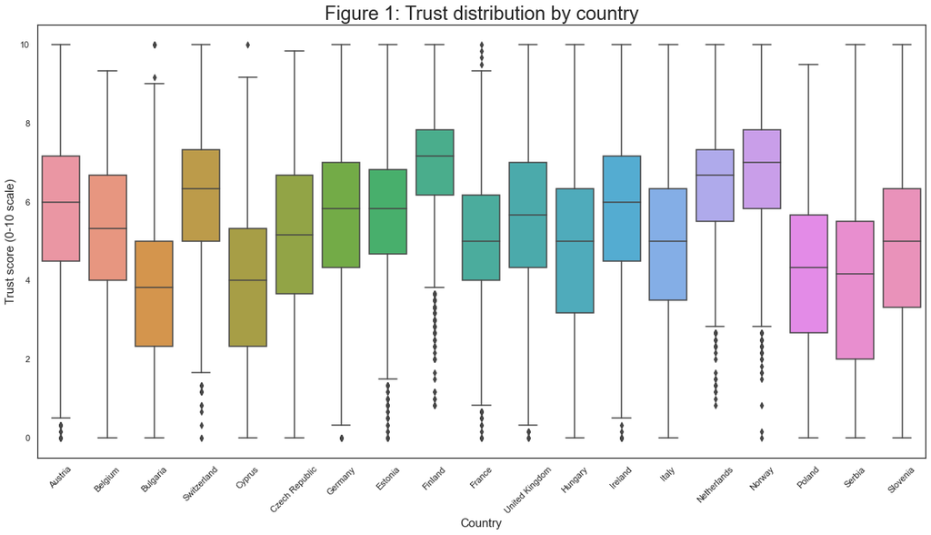

```python
# Plot distribution of trust per country using boxplots
# Plotting
plt.figure(figsize=(20, 10))
sns.boxplot(x = "cntry", y = "trust", data = ess)

# Formatting
plt.title('Figure 1: Trust distribution by country', fontsize='24')
plt.ylabel('Trust score (0-10 scale)', fontsize='15')
plt.xlabel('Country', fontsize='15')
plt.xticks(rotation = 45);
```

# Unsupervised Learning

In this section a K-Means clustering exercise will take place to cluster the observations in terms of social trust, left right scale, legal trust, happiness, religious commitment, and parliamentary trust. In this way, homogenous groups can be identified based on their similarities. All chosen values are measured between 0 – 10. For every variable other than trust the scales are discrete values in increments of 1. As trust is an aggregate variable resulting from a weighted mean, there are many more possible answers.

### *Clustering the data*

```python
# Create a list with the names of the continious variables
cont = ['trust', 'lrscale', 'trstlgl', 'happy', 'rlgdgr', 'trstprl']
```

```python
# Create the datasets to use for clustering
# Raw
ess_raw = ess[cont]
# Standardised - scaling the data by minusing the mean and dividing by std
ess_stded = scale(ess[cont])
# PCA - create PCA estimator with 2 components (2 axis when visualised)
# Create a new data set which contains a transformation of the base data into 2 columns
pca_estimator = PCA(n_components=2)
ess_pca = pca_estimator.fit_transform(ess[cont])
ess_pca = pd.DataFrame(ess_pca, index = ess.index, columns = ["C-1", "C-2"])
```

### *Interpretation of results*

```python
# Create a nested loop which calculates both Calinski and Harabasz, and Silhouette scores for all 3 data sets
seed(1998)
# Create a list outside the group to append to
measurements = []
# For cluster sizes between 3 and 7, fit the KMeans estimator to the 3 data sets
for label_data in [('Raw', ess_raw), ('Standardised', ess_stded), ('PCA', ess_pca)]:
    for i in range(3, 7):
        estimator = KMeans(n_clusters=i)
        estimator.fit(label_data[1])
        # Calculate scores
        chs = calinski_harabasz_score(ess_raw, estimator.labels_)
        sil = silhouette_score(ess_raw, estimator.labels_, metric="euclidean")
        # Append the name of the data, amount of clusters, and both scores to a list
        measurements.append([label_data[0], i, chs, sil])
```

```python
# Create a data frame from the list
k_tests = pd.DataFrame(measurements, columns=["Data", "Clusters", "CHS", "SIL"])
```

```python
# Building a function which finds the 5 largest values in a column and highlights them
def highlight_maxs(col):
    is_large = col.nlargest(5).values
    row_styles = []
    # For value in each column, if the value is one of the 5 highest then turn the value yellow
    for v in col:
        if v in is_large:
            row_styles.append('background-color: yellow')
        else:
            row_styles.append('')
    return row_styles
```

```python
# Formatting
k_tests.style.set_caption('Table 2: Calinski Harabasz and Silhouette scores for the 3 data sets at different cluster sizes')\
.set_table_styles([{'selector': 'caption',
                    'props': [('font-size', '16px')]}]).apply(highlight_maxs, subset=['CHS', 'SIL'])
```

Table 2: Calinski Harabasz and Silhouette scores for the 3 data sets at different cluster sizes

|  | Data | Clusters | CHS | SIL |
| --- | --- | --- | --- | --- |
| 0 | Raw | 3 | 9123.726297 | 0.217436 |
| 1 | Raw | 4 | 7925.907123 | 0.196227 |
| 2 | Raw | 5 | 6851.637645 | 0.173938 |
| 3 | Raw | 6 | 6082.009511 | 0.152390 |
| 4 | Standardised | 3 | 8742.935667 | 0.205779 |
| 5 | Standardised | 4 | 6639.507341 | 0.183951 |
| 6 | Standardised | 5 | 5923.568967 | 0.161483 |
| 7 | Standardised | 6 | 5265.803898 | 0.137312 |
| 8 | PCA | 3 | 9120.953100 | 0.217565 |
| 9 | PCA | 4 | 7921.457429 | 0.196071 |
| 10 | PCA | 5 | 6841.966633 | 0.173583 |
| 11 | PCA | 6 | 6029.714881 | 0.145468 |

The Calinski Harabasz score is a measure of between cluster and inter cluster dispersion. A Silhouette score measures how similar the result is to the mean distance of its own cluster and the next closest cluster. Higher scores are preferable for both and the top 5 are highlighted. Both tests are consistent in their decision: Raw and PCA data at 3/4 clusters, standardised data at 3. Cluster sizes 3 and 4 are taken forward, and Raw and PCA preform best across both these sizes.

However, scores do not show the entire picture and visualisation is a useful aid.

```python
# Create raw labels for 3 and 4 clusters
# Create empty list which the 2 series will be appended to (each series has a different amount of clusters)
raw_labels = []
# Set seed
seed(1998)
# For cluster size 3 and 4 fit a KMeans estimator on raw data
for cluster in [3 , 4]:
    estimator = KMeans(n_clusters = cluster)
    estimator.fit(ess[cont])
    # Append the labels (which cluster each observation is in) to a series with the index of the raw dataset
    raw_labels.append(pd.Series(estimator.labels_, index=ess[cont].index))
# The first series in the raw_labels list is the labels based on raw data for 3 clusters, and the second for 4
kraw3 = raw_labels[0]
kraw4 = raw_labels[1]
```

```python
# Do the same for PCA
# Same process as above but with pca data rather than raw
pca_labels = []
seed(1998)
for cluster in [3 , 4]:
    estimator = KMeans(n_clusters = cluster)
    estimator.fit(ess_pca)
    pca_labels.append(pd.Series(estimator.labels_, index=ess_pca.index))
# The first series in the pca_labels list is the labels based on pca data for 3 clusters, and the second for 4
kpca3 = pca_labels[0]
kpca4 = pca_labels[1]
```

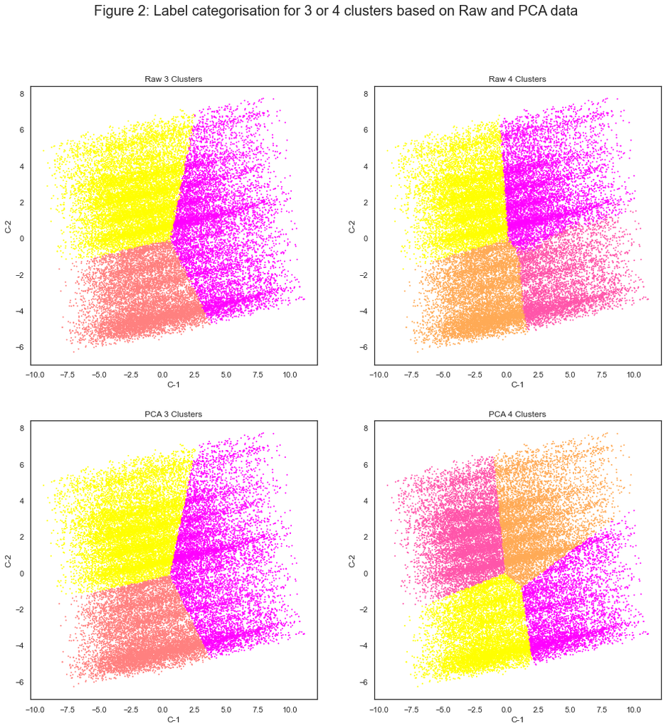

```python
# Visualise (write a function to eliminate repetitive code)
# Plotting
sns.set(font_scale=1, style='white')
# Create a 2x2 grid and set the size
f, axs = plt.subplots(2, 2, figsize=(16, 16))

# The function takes the axes, the cluster labels to use, and a title
def plotpoints(ax, lab, title):
    # Using pca data to plot as it is on 2 axis, but colours are based on the cluster labels
    ess_pca.assign(labels = lab)\
              .plot.scatter('C-1',
                            'C-2',
                            c='labels',
                            s=1,
                            cmap='spring',
                            colorbar=False,
                            ax=ax)
    ax.set_title(title)

plotpoints(axs[0,0], kraw3, 'Raw 3 Clusters')
plotpoints(axs[0,1], kraw4, 'Raw 4 Clusters')
plotpoints(axs[1,0], kpca3, 'PCA 3 Clusters')
plotpoints(axs[1,1], kpca4, 'PCA 4 Clusters')

# Formatting
f.suptitle("Figure 2: Label categorisation for 3 or 4 clusters based on Raw and PCA data", fontsize=20);
```

```python
# Group the dataset by clusters and look at the amount of observations per cluster
grouped4 = ess[cont].groupby(kpca4)
grouped4.size()
```

```
0    5106
1    8671
2    7372
3    8251
dtype: int64
```

Even though the scores were higher for 3 clusters, when visualising 3 the pink cluster is very large so there would be a lot of variation within it. 4 clusters has a more visually appropriate spread and PCA data has more defined separation. Across the 4 PCA clusters there is a decently even distribution of results, with 5106 observations in the smallest cluster and 8671 in the largest.

### *Cluster characterisation*

```python
# Create a 'stacked' data set which has a new row for each column observation
# There are 6 variables in the original data set, so each origianl observation will now be split into 6 observations
# The new 'stacked' data frame will have a new index, keep the old index as an 'ID', state the variable in 'Var'
# and the cluster 'Label'
stack_ess = ess[cont]\
            .stack()\
            .reset_index()\
            .rename(columns={"level_1": "Var",
                             "level_0": "ID",
                             0: "Value"
                            })\
            .join(pd.DataFrame({"Label": kpca4}),
                  on="ID")
```

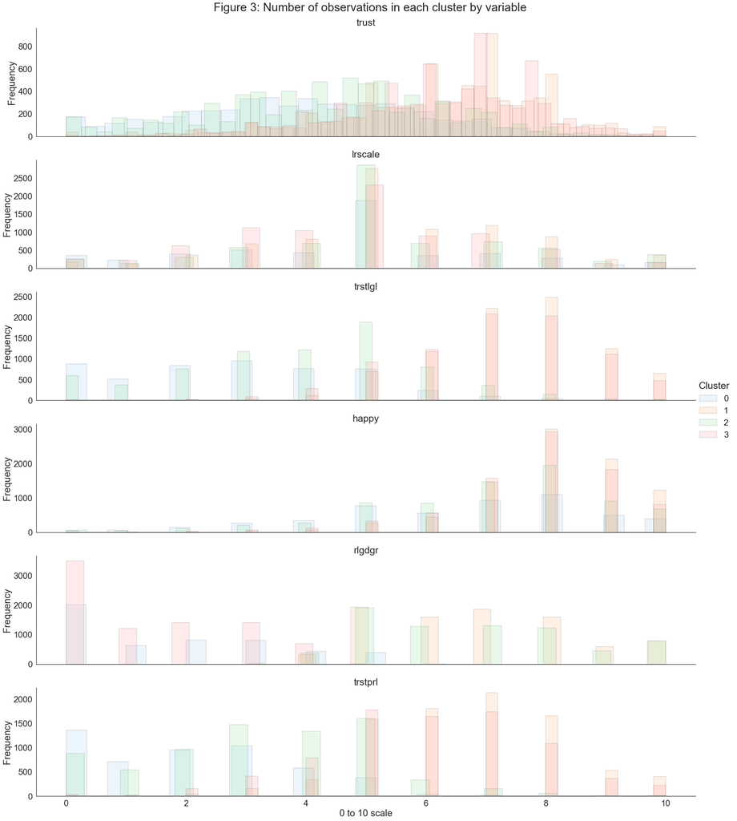

```python
# Visualise the distribution of each variable for each cluster
# Plotting
sns.set(font_scale=2, style='white')
sns.set_palette('pastel')
# On each row of the facet grid will be the variables, and the colours will be the cluster
g = sns.FacetGrid(stack_ess,
                  row="Var",
                  hue="Label",
                  height=5,
                  aspect=5,
                  sharey=False)
# Map histograms to the facet plots of the values
g.map(sns.distplot,
      "Value",
      hist=True,
      #bins=10,
      kde=False,
      hist_kws=dict(edgecolor='grey', alpha=0.2, linewidth=2),
      rug=False)

# Formatting
g.set_axis_labels('0 to 10 scale', 'Frequency')
g.set_titles(col_template='{col_name}', row_template='{row_name}', size='25')
g.fig.suptitle('Figure 3: Number of observations in each cluster by variable', size=30)
g.add_legend(title='Cluster', fontsize=22)
g._legend.get_title().set_fontsize(25)

plt.subplots_adjust(top=0.95);
```

It can be assumed that social, legal, and parliamentary trust are positively associated, with clusters 0 and 2 on the lower end and 1 and 3 on the higher of all 3 variables consistently. This also seems to correlate with happiness, as even though all clusters were skewed to the left with their happiness scores, the clusters with higher trust had higher happiness. The biggest differentiating factor between these 2 sets of clusters is religion, as clusters of high and low trust sit on both ends of the religious scale. Finally, all clusters have a bimodal left right distribution with 0 and 2 peaking in the centre, but 1 and 3 sit slightly centre right and centre left respectively.

# Supervised Learning

### *Building regression models*

The overarching aim of this section will be to explain trust ($y$) as a function of independent variables - $f(x)$. Models can be built which use $x$ to predict trust ($\hat{y}$).

```python
# Build linear model stats way - use a small selection of seemingly relevant variables
rm1 = 'trust ~ happy + agea + trstprl + rlgdgr + sclmeet + gndr'
st_raw = sm.ols(rm1, ess).fit()
st_raw.summary()
```

OLS Regression Results

| Dep. Variable: | trust | R-squared: | 0.213 |
| --- | --- | --- | --- |
| Model: | OLS | Adj. R-squared: | 0.212 |
| Method: | Least Squares | F-statistic: | 881.9 |
| Date: | Sun, 07 Mar 2021 | Prob (F-statistic): | 0.00 |
| Time: | 11:38:05 | Log-Likelihood: | -59353. |
| No. Observations: | 29400 | AIC: | 1.187e+05 |
| Df Residuals: | 29390 | BIC: | 1.188e+05 |
| Df Model: | 9 |  |  |
| Covariance Type: | nonrobust |  |  |

|  | coef | std err | t | P>\|t\| | [0.025 | 0.975] |
| --- | --- | --- | --- | --- | --- | --- |
| Intercept | 2.3861 | 0.066 | 36.234 | 0.000 | 2.257 | 2.515 |
| sclmeet[T.never] | -1.1807 | 0.093 | -12.684 | 0.000 | -1.363 | -0.998 |
| sclmeet[T.once a month or less] | -0.3355 | 0.040 | -8.354 | 0.000 | -0.414 | -0.257 |
| sclmeet[T.once or more a week] | 0.1277 | 0.034 | 3.724 | 0.000 | 0.060 | 0.195 |
| sclmeet[T.several times a month] | -0.1059 | 0.039 | -2.750 | 0.006 | -0.181 | -0.030 |
| gndr[T.male] | -0.0815 | 0.021 | -3.795 | 0.000 | -0.124 | -0.039 |
| happy | 0.2165 | 0.006 | 35.102 | 0.000 | 0.204 | 0.229 |
| agea | 0.0052 | 0.001 | 8.550 | 0.000 | 0.004 | 0.006 |
| trstprl | 0.2805 | 0.004 | 64.281 | 0.000 | 0.272 | 0.289 |
| rlgdgr | -0.0441 | 0.004 | -12.474 | 0.000 | -0.051 | -0.037 |

| Omnibus: | 867.190 | Durbin-Watson: | 1.877 |
| --- | --- | --- | --- |
| Prob(Omnibus): | 0.000 | Jarque-Bera (JB): | 949.559 |
| Skew: | -0.424 | Prob(JB): | 6.40e-207 |
| Kurtosis: | 3.239 | Cond. No. | 510. |

Warnings:  
[1] Standard Errors assume that the covariance matrix of the errors is correctly specified.

All coefficients are statistically significant (p < 0.05). Those who never meet up with others tend to answer 1.2 marks lower on the trust scale than those who meet people every day, and every other category are less trusting except those who meet once or more a week. This is an interesting result as it suggests there is a limit on how much you can socialise before you become less trusting. Males tend to answer 0.1 point less on the trust scale than females. For every 1-point increase of happiness, trust increases by 0.22, and for every year of age trust increases by 0.005. This suggests older and happier people are more trusting. However, it is not always the case that relationships with age are linear so this result must be approached with caution. Finally, parliamentary trust is positively associated with social trust and religion has a negative association.

```python
# Check for skew
for value in [ess['trust']]:
    print(value.mean(), value.median())
```

```
5.350471768707497 5.5
```

There is a slight left skew so there is a chance a log measure of trust will provide better results for a linear model.

```python
# Create the log model
lm1 = 'np.log1p(trust) ~ happy + agea + trstprl + rlgdgr + sclmeet + gndr'
st_log = sm.ols(lm1, ess).fit()
```

```python
# Print r2 values for comparision
for value in [st_raw, st_log]:
    print(value.rsquared)
```

```
0.21263509104669454
0.19005998352865727
```

The raw model has a higher $r^2$ and can explain around 21% of variation as opposed to 19% with the log – so has a better performance. Regardless, both $r^2$ values are relatively low. One way to improve this is to add more independent variables to the model.

```python
#Create new model with more predictors
rm2 = 'trust ~ happy + lrscale + trstlgl + trstprl + agea + rlgdgr + sclmeet + cntry + gndr + dscrgrp + aesfdrk'
st_raw2 = sm.ols(rm2, ess).fit()
st_raw2.summary()
```

OLS Regression Results

| Dep. Variable: | trust | R-squared: | 0.295 |
| --- | --- | --- | --- |
| Model: | OLS | Adj. R-squared: | 0.295 |
| Method: | Least Squares | F-statistic: | 373.0 |
| Date: | Sun, 07 Mar 2021 | Prob (F-statistic): | 0.00 |
| Time: | 11:38:06 | Log-Likelihood: | -57721. |
| No. Observations: | 29400 | AIC: | 1.155e+05 |
| Df Residuals: | 29366 | BIC: | 1.158e+05 |
| Df Model: | 33 |  |  |
| Covariance Type: | nonrobust |  |  |

|  | coef | std err | t | P>\|t\| | [0.025 | 0.975] |
| --- | --- | --- | --- | --- | --- | --- |
| Intercept | 3.0894 | 0.081 | 37.927 | 0.000 | 2.930 | 3.249 |
| sclmeet[T.never] | -1.0512 | 0.090 | -11.718 | 0.000 | -1.227 | -0.875 |
| sclmeet[T.once a month or less] | -0.3055 | 0.039 | -7.739 | 0.000 | -0.383 | -0.228 |
| sclmeet[T.once or more a week] | 0.0384 | 0.033 | 1.163 | 0.245 | -0.026 | 0.103 |
| sclmeet[T.several times a month] | -0.1041 | 0.037 | -2.796 | 0.005 | -0.177 | -0.031 |
| cntry[T.Belgium] | -0.1609 | 0.057 | -2.833 | 0.005 | -0.272 | -0.050 |
| cntry[T.Bulgaria] | -0.4869 | 0.065 | -7.469 | 0.000 | -0.615 | -0.359 |
| cntry[T.Cyprus] | -1.0799 | 0.084 | -12.863 | 0.000 | -1.244 | -0.915 |
| cntry[T.Czech Republic] | -0.1488 | 0.055 | -2.701 | 0.007 | -0.257 | -0.041 |
| cntry[T.Estonia] | 0.2139 | 0.057 | 3.767 | 0.000 | 0.103 | 0.325 |
| cntry[T.Finland] | 0.9133 | 0.057 | 16.154 | 0.000 | 0.802 | 1.024 |
| cntry[T.France] | -0.2990 | 0.056 | -5.325 | 0.000 | -0.409 | -0.189 |
| cntry[T.Germany] | -0.0057 | 0.052 | -0.110 | 0.912 | -0.108 | 0.097 |
| cntry[T.Hungary] | -0.3672 | 0.062 | -5.958 | 0.000 | -0.488 | -0.246 |
| cntry[T.Ireland] | 0.3762 | 0.055 | 6.785 | 0.000 | 0.268 | 0.485 |
| cntry[T.Italy] | -0.3236 | 0.055 | -5.880 | 0.000 | -0.431 | -0.216 |
| cntry[T.Netherlands] | 0.4264 | 0.058 | 7.319 | 0.000 | 0.312 | 0.541 |
| cntry[T.Norway] | 0.5779 | 0.062 | 9.389 | 0.000 | 0.457 | 0.699 |
| cntry[T.Poland] | -0.7968 | 0.065 | -12.253 | 0.000 | -0.924 | -0.669 |
| cntry[T.Serbia] | -1.1426 | 0.064 | -17.959 | 0.000 | -1.267 | -1.018 |
| cntry[T.Slovenia] | -0.3455 | 0.067 | -5.189 | 0.000 | -0.476 | -0.215 |
| cntry[T.Switzerland] | 0.1105 | 0.061 | 1.820 | 0.069 | -0.008 | 0.230 |
| cntry[T.United Kingdom] | 0.1024 | 0.055 | 1.876 | 0.061 | -0.005 | 0.209 |
| gndr[T.male] | -0.1570 | 0.021 | -7.452 | 0.000 | -0.198 | -0.116 |
| dscrgrp[T.yes] | -0.2393 | 0.040 | -6.000 | 0.000 | -0.318 | -0.161 |
| aesfdrk[T.unsafe] | -0.3517 | 0.030 | -11.573 | 0.000 | -0.411 | -0.292 |
| aesfdrk[T.very safe] | 0.1901 | 0.024 | 7.783 | 0.000 | 0.142 | 0.238 |
| aesfdrk[T.very unsafe] | -0.7501 | 0.057 | -13.129 | 0.000 | -0.862 | -0.638 |
| happy | 0.1400 | 0.006 | 22.786 | 0.000 | 0.128 | 0.152 |
| lrscale | -0.0353 | 0.005 | -7.443 | 0.000 | -0.045 | -0.026 |
| trstlgl | 0.1186 | 0.005 | 21.846 | 0.000 | 0.108 | 0.129 |
| trstprl | 0.1526 | 0.005 | 28.095 | 0.000 | 0.142 | 0.163 |
| agea | 0.0055 | 0.001 | 9.522 | 0.000 | 0.004 | 0.007 |
| rlgdgr | -0.0106 | 0.004 | -2.969 | 0.003 | -0.018 | -0.004 |

| Omnibus: | 498.990 | Durbin-Watson: | 2.007 |
| --- | --- | --- | --- |
| Prob(Omnibus): | 0.000 | Jarque-Bera (JB): | 533.217 |
| Skew: | -0.307 | Prob(JB): | 1.63e-116 |
| Kurtosis: | 3.244 | Cond. No. | 952. |

Warnings:  
[1] Standard Errors assume that the covariance matrix of the errors is correctly specified.

happy, trstprl, sclmeet, rlgdgr, and age all show similar associations in the same direction. Gender has the same relationship pattern as before, although the negative association between males and trust has increased. Cyprus, Serbia, and Poland have the strongest negative association with trust compared to Austria, whereas Finland, Norway, and the Netherlands have the strongest positive associations (answering 0.91, 0.58, and 0.43 points more on the trust scale). Those from discriminated groups answer 0.24 points less than those not from these groups, and those who feel unsafe and very unsafe have less trust than those who feel safe and very safe. Left leaning respondents are more trusting as for every 1 point towards the right trust decreases by 0.04. Finally, legal trust is positively associated with social trust.

```python
#Create new log model with more predictors
lm2 = 'np.log1p(trust) ~ happy + lrscale + trstprl + trstlgl + agea + rlgdgr + sclmeet + cntry + gndr + dscrgrp + aesfdrk'
st_log2 = sm.ols(lm2, ess).fit()
```

```python
# Display r2 scores
r2_res = pd.Series({'Raw 1': st_raw.rsquared,
                    'Log 1': st_log.rsquared,
                    'Raw 2': st_raw2.rsquared,
                    'Log 2': st_log2.rsquared})
r2_res
```

```
Raw 1    0.212635
Log 1    0.190060
Raw 2    0.295358
Log 2    0.269132
dtype: float64
```

Both models with more independent variables perform with higher $r^2$ scores. However, this does not necessarily mean they will make great predictors.

Therefore, all 4 models will be analysed further.

### *Predictions*

```python
# Save predicted labels (values)
lm_raw_lbls = st_raw.fittedvalues
lm_log_lbls = np.exp(st_log.fittedvalues)
lm_raw2_lbls = st_raw2.fittedvalues
lm_log2_lbls = np.exp(st_log2.fittedvalues)
```

```python
# Write a function that plots a histogram given the data, legend label and axis to plot on
def plothist(data, lab, ax):
    sns.distplot(data, kde=False, bins=20, ax=ax, label=lab, \
                 hist_kws=dict(edgecolor='grey', alpha=0.2, linewidth=2))
```

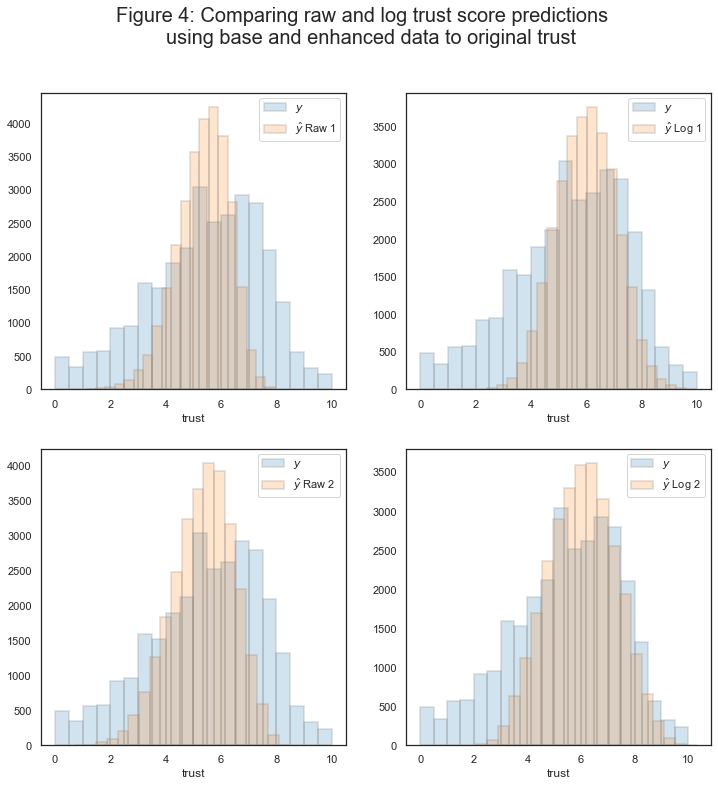

```python
# Plot the 4 labels all against the original value for direct comparision
# Plotting
sns.set(font_scale=1, style='white')
sns.set_palette('tab10')
f, axs = plt.subplots(2, 2, figsize=(12, 12))
# Raw trust and less predictors
plothist(ess['trust'], '$y$', axs[0][0])
plothist(lm_raw_lbls, '$\hat{y}$ Raw 1', axs[0][0])

# Log trust and less predictors
plothist(ess['trust'], '$y$', axs[0][1])
plothist(lm_log_lbls, '$\hat{y}$ Log 1', axs[0][1])

# Raw trust and more predictors
plothist(ess['trust'], '$y$', axs[1][0])
plothist(lm_raw2_lbls, '$\hat{y}$ Raw 2', axs[1][0])

# Log trust and more predictors
plothist(ess['trust'], '$y$', axs[1][1])
plothist(lm_log2_lbls, '$\hat{y}$ Log 2', axs[1][1])

# Formatting
axs[0][0].legend()
axs[0][1].legend()
axs[1][0].legend()
axs[1][1].legend()
f.suptitle('Figure 4: Comparing raw and log trust score predictions \n  using base and enhanced data to original trust', fontsize=20)
plt.show();
```

All 4 sets of labels replicate the overall shape quite nicely but perform poorly at the upper and lower ends. Both models with less predictors have a slightly narrower distribution, and all models over-predict towards the centre. The log results have a similar spread to the raw but are shifted to the right preforming better at the higher end of the scale but worse at the lower.

Logarithms are a useful tool to standardise data to better suit linear relationships, so if the log data does not perform better at the linear stage ($r^2$ or visualisation) then it can be dropped.

No model or variable combination is perfect. A random forest (RF) model can be introduced. This could improve the performance as the combination of independent variables used to explain trust may not be linear in their relationship. Forcing them into this may lead to a model which picks up excessive noise.

```python
# Build the data set with less predictors (X) for sklearn models - necessary for RF
# Just categorical variables for dummy coding
cat = ['sclmeet', 'gndr']
cat_dum = pd.get_dummies(ess[cat])
# Create list of variables to drop
cat_drop = ['sclmeet_every day', 'gndr_female']
# make new list of continious variables without trust
cont_ind = ['happy', 'agea', 'trstprl', 'rlgdgr']
# Create a dataset for the model - all continious variables (bar the dependant), plus dummy coded categorical
X = pd.concat([ess[cont_ind], cat_dum.drop(cat_dum[cat_drop],axis=1)], axis=1)
```

```python
# Build the data set with more predictors (X2) for sklearn models
# Same process as above
cat2 = ['sclmeet', 'gndr', 'cntry', 'dscrgrp', 'aesfdrk']
cat_dum2 = pd.get_dummies(ess[cat2])
cat_drop2 = ['sclmeet_every day', 'gndr_female', 'cntry_Austria', 'dscrgrp_no', 'aesfdrk_safe']
cont_ind2 = ['happy', 'agea', 'lrscale', 'trstprl', 'rlgdgr', 'trstlgl']
X2 = pd.concat([ess[cont_ind2], cat_dum2.drop(cat_drop2, axis=1)], axis=1)
```

```python
# Fit a random forest models sklearn way for X
# This process will predict trust using the RF model rather than a linear model
# Create the regressor (RF in this case - could be linear if you wanted to build your linear model this way)
rf_raw = RandomForestRegressor(n_estimators=100,
                               max_features=None)
# Fit to the X (the dataset with less variables) and y (trust)
rf_raw.fit(X, ess['trust'])
# Predict trust
rf_raw_lbls = rf_raw.predict(X)
```

```python
# Fit a random forest models sklearn way for X2
# Create the regressor
rf_raw2 = RandomForestRegressor(n_estimators=100,
                               max_features=None)
# Fit to the X2 (the dataset with all the variables) and y (trust)
rf_raw2.fit(X2, ess['trust'])
# Predict trust
rf_raw2_lbls = rf_raw2.predict(X2)
```

```python
# Convert labels to series rather than numpy arrays
rf_raw_lbls = pd.Series(rf_raw_lbls)
rf_raw2_lbls = pd.Series(rf_raw2_lbls)
```

```python
# Create loop to print the data and model used plus a description of the values
for label, series in [('RF Raw',rf_raw_lbls), ('RF Raw 2', rf_raw2_lbls), ('True Trust',ess['trust'])]:
    print(label)
    print(series.describe())
```

```
RF Raw
count    29400.000000
mean         5.339565
std          1.521569
min          0.198200
25%          4.371250
50%          5.497225
75%          6.471204
max          9.644900
dtype: float64
RF Raw 2
count    29400.000000
mean         5.343185
std          1.574834
min          0.099300
25%          4.308600
50%          5.491150
75%          6.516925
max          9.673100
dtype: float64
True Trust
count    29400.000000
mean         5.350472
std          2.053228
min          0.000000
25%          4.000000
50%          5.500000
75%          6.830000
max         10.000000
Name: trust, dtype: float64
```

From this perspective the raw RF predictions seem better at matching the distribution of trust than the LM predictions.

This is only an overview; closer interpretation will be given to the results in the next section.

### *Evaluation - without cross validation*

```python
# Create a dataframe with all the predicted values for both datasets and models
all_lab = pd.DataFrame({'LM Raw': lm_raw_lbls,
                       'LM Raw 2': lm_raw2_lbls,
                       'RF Raw': rf_raw_lbls,
                       'RF Raw 2': rf_raw2_lbls,
                       'Truth': ess['trust']})
```

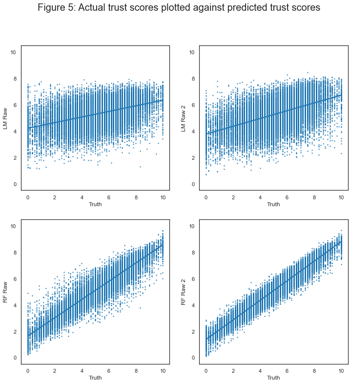

```python
# Plot 2x2 scatter plots of all these predictions against trust
f, axs = plt.subplots(2, 2, figsize=(12, 12))
axs = axs.flatten()
# Use a loop, enumerate returns the index and value
for i, m in enumerate(all_lab.columns.drop('Truth')):
    # Plot on index value (0-3)
    ax = axs[i]
    ax.set_xlim(-0.5,10.5)
    ax.set_ylim(-0.5,10.5)
    # Plot x = truth and y = the predicted values
    sns.regplot('Truth',
                m,
                all_lab,
                ci=None,
                scatter_kws={'s':2},
                ax=ax)

# Formatting
f.suptitle('Figure 5: Actual trust scores plotted against predicted trust scores', fontsize=20)
plt.show();
```

The spread of points and slope of the line of best fit are a great way to see each individual point’s accuracy and overall error.

It is clear that RF predictions are more accurate. Linear models over and underpredict to a higher extent, particularly at the top and bottom ends of the scale. Overall, the predictions based on Raw 2 data created with a RF estimator preform the best – but there is still a tendency to under predict at the top and over predict at the bottom, just not to the same extent as the others.

```python
# Creating a series of scores for each set of labels - for later use
# Funtion takes the scoring type
def make_scoring_series(score_fn):
    return pd.Series({'LM Raw': score_fn(ess['trust'], lm_raw_lbls),
                      'LM Raw 2': score_fn(ess['trust'], lm_raw2_lbls),
                      'RF Raw': score_fn(ess['trust'], rf_raw_lbls),
                      'RF Raw 2': score_fn(ess['trust'], rf_raw2_lbls)})

# Use the function and save results
r2 = make_scoring_series(metrics.r2_score)
mse = make_scoring_series(metrics.mean_squared_error)
mae = make_scoring_series(metrics.mean_absolute_error)
me = mse.apply(np.sqrt)
```

```python
# Create a dataframe for later use using the series' produced above
noncv_scres = pd.DataFrame({'MAE': mae,
                           'MSE': mse,
                           'R2': r2,
                           'ME': me,
                           'CV': 'Not cross validated'})
```

All we can gather so far is how good our models are at predicting values based on data they have already seen. Until the models have been cross validated (CV) – assessed based on their predictive performance for unseen data – there is a chance the model is over fit to the sample at hand. This would mean that the model is too entuned with the seen data, picking up excess noise only relevant to the specific sample, not signalling the true extent of relationships between variables. If we want to predict trust in an individual who is not in the dataset then it would be unwise to decide which model is more useful until CV is undertaken.

Performance scores give a much more focused evaluation than a visualisation. All scores (CV’d and not CV’d) will be interpreted at the end.

### *Evaluation - with cross validation*

To cross validate, the original $y$ – trust, and $x$ – the predictors, are split into testing and training sub samples (an 20/80 split). The model is fit on the training $x$ and $y$ subset and predictions are made for trust on the test $x$. These predictions can then be compared to the test $y$ - unseen trust values.

The code below preforms a K-fold CV exercise. It completes the above process 5 times over. This is because there is a chance the test/train split could occur in such a way that results are biased towards one specific collection of observations. A k-fold validating process runs this split k number of times (in this case 5), splitting the data into 5 equal samples then using each one as the testing sample. 5 sets of predictions are produced, therefore, 5 performance scores. Means of the scores are taken to calculate the average performance score across the 5 folds.

```python
# Create a copy of X and X2 and add trust
Xnew = X.copy(deep=True)
Xnew['trust'] = ess['trust']
X2new = X2.copy(deep=True)
X2new['trust'] = ess['trust']
```

```python
# Shuffle it so the dataset is in a random order(the order is country based so this will randomise that)
# The cross_validate method does not shuffle itself
Xshuff = Xnew.sample(frac=1)
X2shuff = X2new.sample(frac=1)
```

```python
# Build a function that calculates MAE, MSE, ME, and R2 for LM and RF estimators
est_linear = LinearRegression()
est_forest = RandomForestRegressor(n_estimators=100, max_features=None)

# It takes a lable (whether it is RF or LM) plus one of the above estimators, an X and y
def cvscores(label, est, x, y):
    # Create a list of scores - we want mean absoloute error, squared error, and r2
    scores = ['neg_mean_absolute_error', 'neg_mean_squared_error', 'r2']
    # Save the cross validating results to an object (this method returns a dictionary of all of the scores for each fold (5 in total))
    cv = cross_validate(est, x, y, cv=5, scoring=scores)
    # The keys are the names of the scores, so the values can be extracted and the mean take (summarise all 5 scores into 1)
    mae = -cv['test_neg_mean_absolute_error'].mean()
    mses = -cv['test_neg_mean_squared_error']
    mse = mses.mean()
    # The sqrt of the mean squared error is the mean error (a value directly relatable to the trust scale)
    me = np.sqrt(mses).mean()
    r2 = cv['test_r2'].mean()
    # Return a series
    return pd.Series({'Label': label,
                      'MAE': mae,
                      'MSE': mse,
                      'R2': r2,
                      'ME': me,
                      'CV': 'Cross validated'})
```

```python
# Create a data frame with cross validated RF and LM estimator scores
base_cv_scres = pd.DataFrame([
    cvscores('LM Raw', est_linear, Xshuff.drop('trust', axis=1), Xshuff['trust']),
    cvscores('LM Raw 2', est_linear, X2shuff.drop('trust', axis=1), X2shuff['trust']),
    cvscores('RF Raw', est_forest, Xshuff.drop('trust', axis=1), Xshuff['trust']),
    cvscores('RF Raw 2', est_forest, X2shuff.drop('trust', axis=1), X2shuff['trust'])])
```

```python
# Reset index to match the non cv scores data frame
cv_scres = base_cv_scres.set_index('Label', drop=True)
cv_scres.index.name = None
```

```python
# Concat the 2 tables of scores
all_scres = pd.concat([noncv_scres, cv_scres])
# Add a new column with the data type as the value
all_scres['Data'] = all_scres.index
# Create a multi index table with CV and Data
all_scres = all_scres.set_index(['CV', 'Data'])
```

```python
# Formatting
all_scres.style.set_caption('Table 3: Preformance scores for RF and LM models - with and without cross validation')\
.set_table_styles([{'selector': 'caption',
                    'props': [('font-size', '18px')]}])
```

Table 3: Preformance scores for RF and LM models - with and without cross validation

| CV | Data | MAE | MSE | R2 | ME |
| --- | --- | --- | --- | --- | --- |
| Not cross validated | LM Raw | 1.444775 | 3.319216 | 0.212635 | 1.821872 |
|  | LM Raw 2 | 1.358642 | 2.970488 | 0.295358 | 1.723510 |
|  | RF Raw | 0.636825 | 0.695412 | 0.835038 | 0.833914 |
|  | RF Raw 2 | 0.513759 | 0.433873 | 0.897079 | 0.658691 |
| Cross validated | LM Raw | 1.445377 | 3.322745 | 0.211627 | 1.822821 |
|  | LM Raw 2 | 1.360454 | 2.978458 | 0.293227 | 1.725742 |
|  | RF Raw | 1.548749 | 3.852177 | 0.085964 | 1.962688 |
|  | RF Raw 2 | 1.385048 | 3.110879 | 0.261761 | 1.763729 |

The $r^2$ score is the proportion of variation in trust that is explained by $x$ (predictors), and a higher score is better. The mean squared error is the mean of the difference between all observed trust and predicted trust values, squared. A lower score is more desirable. The ME (mean error) is an extension of the MSE, taking the square route to make it an interpretable value which is relative to the data (in this case points on the trust scale). The MAE is also similar to the MSE, but the mean error is not squared.

First, I will look at not CV’d scores then compare. Both RF models perform very well, with small errors (average trust error is 0.83 Raw and 0.66 Raw 2). The $r^2$ scores are 0.84 and 0.90 which are high, especially when compared to the LM’s 0.21 and 0.30 and mean errors 1.82 and 1.73 – relatively large average errors on a 0 – 10 scale. Models with more predictors perform better than their counterparts. Overall, the RF out preforms the LM with both sets of predictors.

When CV’d scores are considered the results are mixed. The LMs preform almost identically with the non CV’d scores, and more predictors are still better. There is little evidence of overfitting in this case, however, the scores are not that impressive so trust is not an exact function of a linear combination of the predictors. What is very surprising is the performance of the CV’d RF models. The error scores are more than twice as large and the $r^2$ is much smaller – particularly for RF Raw. This means the original non cross-validated model was overfit to the data. The RF CV’d model actually preforms worse than the linear CV’d model, even though the non-CV’d RF model preformed a lot better.

As the data set is big and the model was given a relatively large selection of predictors the non-CV RF model has been able to almost replicate the data. Experimenting with hyper-parameterising could reduce this issue, allowing the model to work with an optimal number of $x$ values and estimators.

If your goal were to predict values in seen data, the RF Raw 2 model preforms best. However, to make predictions based on unseen data the safer option is the Raw 2 LM – but it is still not an excellent predictor of trust.

# Bibliography

Bauer, P.C. and Freitag, M. 2017. Measuring Trust [Online] (E. M. Uslaner, ed.). Oxford University Press. [Accessed 7 April 2020]. Available from: http://oxfordhandbooks.com/view/10.1093/oxfordhb/9780190274801.001.0001/oxfordhb-9780190274801-e-1.

Bjørnskov, C. 2007. Determinants of generalized trust: A cross-country comparison. Public Choice. 130(1–2), pp.1–21.

Reeskens, T. and Hooghe, M. 2007. Cross-cultural measurement equivalence of generalized trust. Evidence from the European Social Survey (2002 and 2004). Social Indicators Research. 85(3), pp.515–532.

Torpe, L. and Lolle, H. 2011. Identifying Social Trust in Cross-Country Analysis: Do We Really Measure the Same? Social Indicators Research. 103(3), pp.481–500.